# Results from fitting to reference p-curves

# 1. Target p-curve: Sotola (2023):

## Visualisations of best simulations in each world

You can visually inspect the fit of the top 5 (where available) simulations in each world (in blue) to the target p-curve (in black). Note that the Flat World only involved one simuulation.

**Realistic: Multiples DVs**

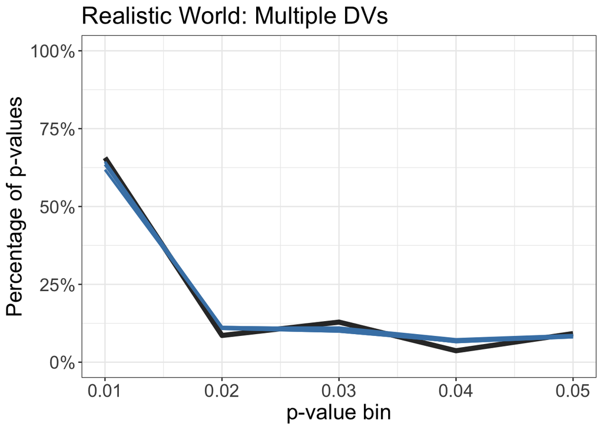

```r
plot_pcurves(simres |> filter(condition == "multDV_realistic"), poriginal = simplify2array(pcurves[1, paste0("p", 1:5)]), n_best = 5, GOF="g2", n_studies = pcurves$nsig[1], tol = 1e-6, title = "Realistic World: Multiple DVs")
```

**Realistic: Optional Stopping**

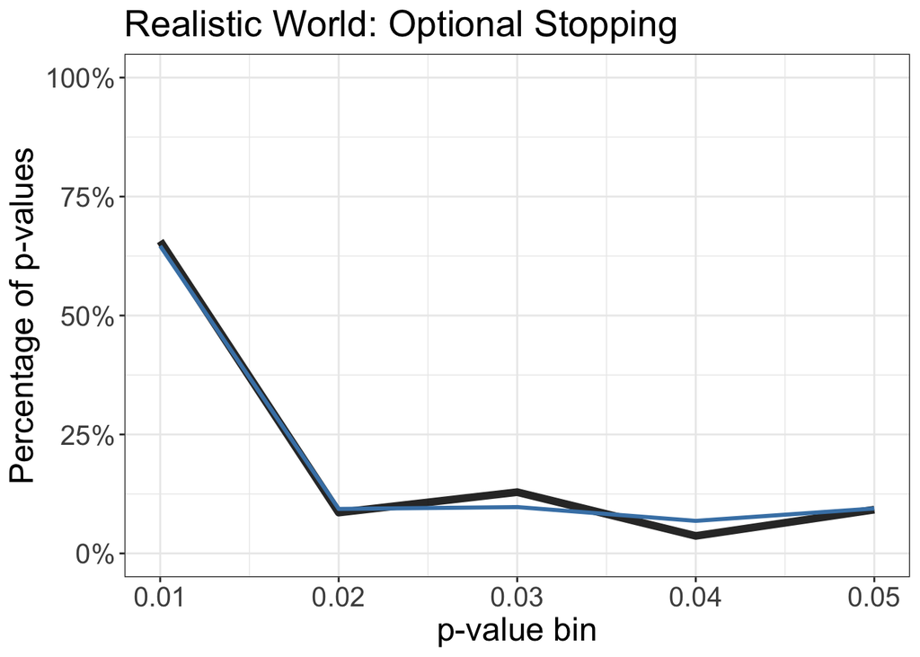

```r
plot_pcurves(simres |> filter(condition == "optStop_realistic"), poriginal = simplify2array(pcurves[1, paste0("p", 1:5)]), n_best = 1, GOF="g2", n_studies = pcurves$nsig[1], tol = 1e-6, title = "Realistic World: Optional Stopping")
```

**Worst: Multiple DVs**

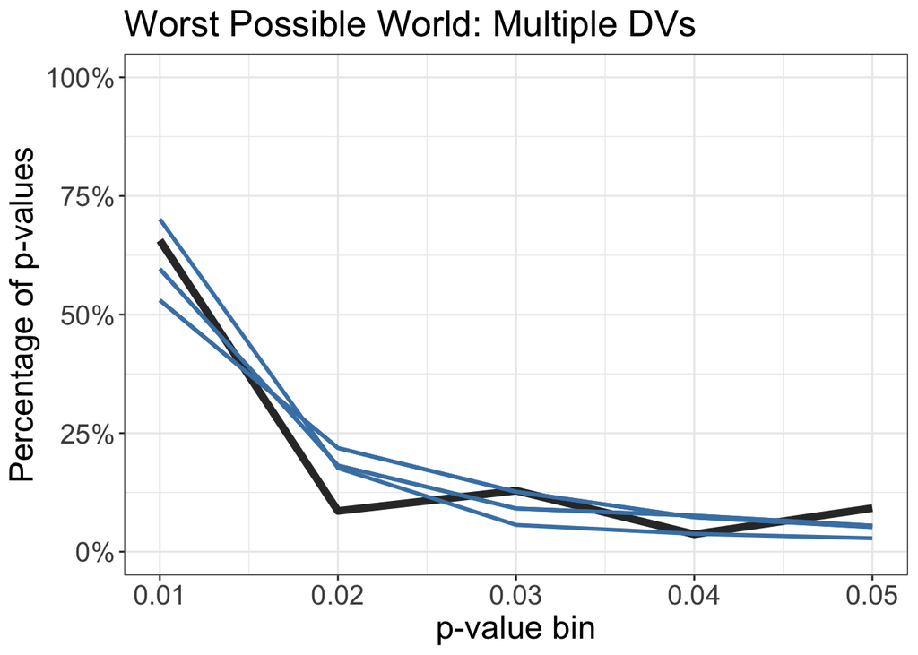

```r
plot_pcurves(simres |> filter(condition == "multDV_worst"), poriginal = simplify2array(pcurves[1, paste0("p", 1:5)]), n_best = 5, GOF="g2", n_studies = pcurves$nsig[1], tol = 1e-6, title = "Worst Possible World: Multiple DVs")
```

**Worst: Optional Stopping**

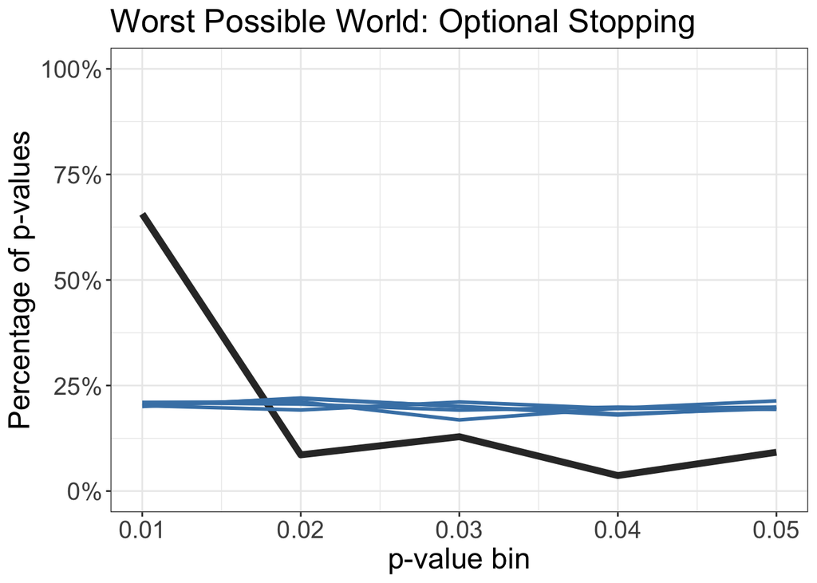

```r
plot_pcurves(simres |> filter(condition == "optStop_worst"), poriginal = simplify2array(pcurves[1, paste0("p", 1:5)]), n_best = 5, GOF="g2", n_studies = pcurves$nsig[1], tol = 1e-6, title = "Worst Possible World: Optional Stopping")
```

**Perfect**

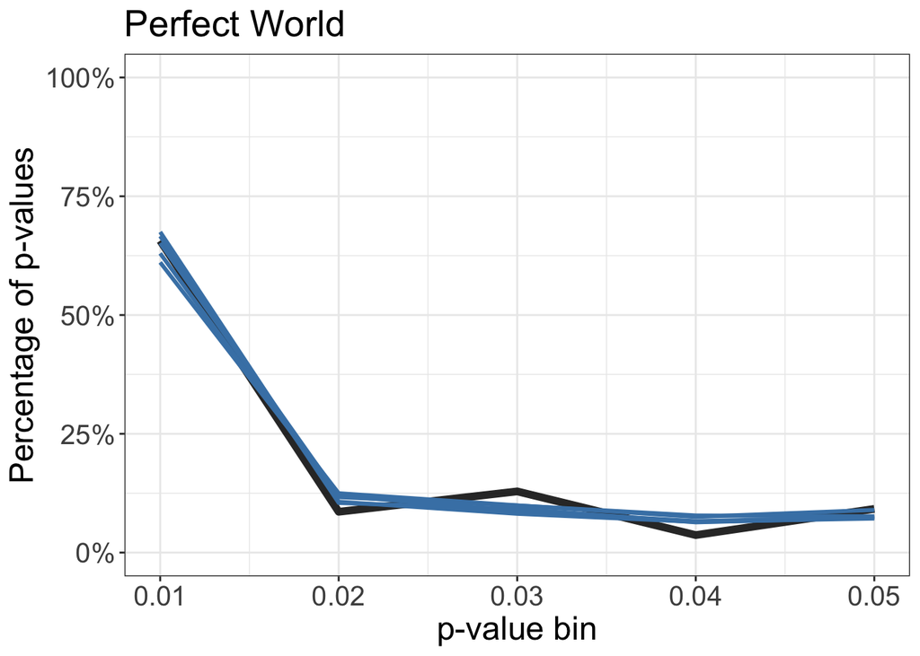

```r
plot_pcurves(simres |> filter(condition == "multDV_perfect"), poriginal = simplify2array(pcurves[1, paste0("p", 1:5)]), n_best = 5, GOF="g2", n_studies = pcurves$nsig[1], tol = 1e-6, title = "Perfect World")
```

**Flat**

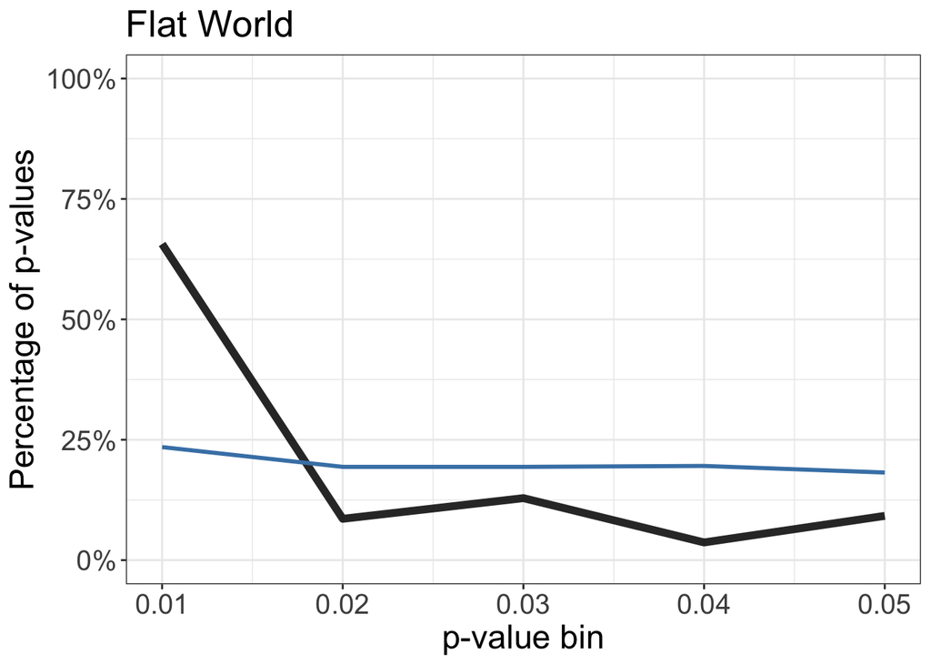

```r
plot_pcurves(simres |> filter(condition == "multDV_H0"), poriginal = simplify2array(pcurves[1, paste0("p", 1:5)]), n_best = 1, GOF="g2", n_studies = pcurves$nsig[1], tol = 1e-6, title = "Flat World")
```

## Overview of best fitting simulations in each world

These fit indices reflect the fit of the best-fitting simulation in each condition/ world. Lower numbers indicate better fit. Note that BIC is a transformation of G2 that penalises for model complexity. ::: {.cell}

```r
fit_tab <- simres %>%
  group_by(condition) %>%
  summarise(
    G2   = min(fit_sotola_g2),
    BIC  = min(BIC_sotola),
    Chi2 = min(fit_sotola_chi2),
    RMSE = min(fit_sotola_rmse)
  )

fit_tab %>%
  mutate(condition = recode(condition, !!!condition_labels)) %>%
  mutate(across(
    -condition,
    ~ cell_spec(sprintf("%.2f", .x), bold = .x == min(.x))
  )) %>%
  kbl(escape = FALSE) %>%
  kable_styling()
```

| condition | G2 | BIC | Chi2 | RMSE |
| --- | --- | --- | --- | --- |
| Flat World | 139.56 | 139.56 | 164.99 | 0.21 |
| Perfect World | 5.62 | 20.90 | 5.57 | 0.02 |
| Realistic World: Multiple DVs | 4.55 | 35.11 | 4.14 | 0.02 |
| Worst World: Multiple DVs | 20.97 | 36.25 | 19.18 | 0.06 |
| Realistic World: Optional stopping | 4.50 | 40.16 | 4.17 | 0.02 |
| Worst World: Optional stopping | 160.54 | 180.91 | 200.30 | 0.23 |

:::

According to G2, the Realistic World: Optional stopping contained the best-fitting simulation to the target p-curve. Once model complexity is accounted for, the Perfect World contained the simulation with the best fit to the target p-curve. Results for chi-squared and RMSE are also provided as robustness checks.

## What were the top 10 best fitting simulations (according to G^2)?

These rows reflect the 10 simulations that had the best fit to the target p-curve according to G^2. (Scroll to see the other fit indices for these simulations.)

```r
simres |> arrange(fit_sotola_g2) |> slice(1:10) |>
  select(condition, nvar, r, d, prop_Hacker, prop_H1, het, strategy, nmin, nmax, stepsize, contains("sotola")) |>
  kbl(digits = 2) |>
  kable_styling() |>
  scroll_box(width = "100%", height = "400px")
```

| condition | nvar | r | d | prop_Hacker | prop_H1 | het | strategy | nmin | nmax | stepsize | fit_sotola_g2 | fit_sotola_chi2 | fit_sotola_rmse | BIC_sotola |
| --- | --- | --- | --- | --- | --- | --- | --- | --- | --- | --- | --- | --- | --- | --- |
| optStop_realistic | NA | NA | 0.7 | 0.25 | 0.2 | 0.0 | NA | 444 | 1063 | 100 | 4.50 | 4.17 | 0.02 | 40.16 |
| multDV_realistic | 5 | 0.3 | 0.6 | 0.10 | 0.3 | 0.2 | 1 | NA | NA | NA | 4.55 | 4.14 | 0.02 | 35.11 |
| multDV_realistic | 5 | 0.3 | 0.6 | 0.10 | 0.3 | 0.2 | 2 | NA | NA | NA | 4.55 | 4.14 | 0.02 | 35.11 |
| multDV_realistic | 5 | 0.9 | 0.8 | 0.50 | 0.2 | 0.2 | 1 | NA | NA | NA | 4.82 | 4.49 | 0.02 | 35.38 |
| multDV_realistic | 5 | 0.9 | 0.8 | 0.50 | 0.2 | 0.2 | 2 | NA | NA | NA | 4.82 | 4.49 | 0.02 | 35.38 |
| optStop_realistic | NA | NA | 0.7 | 0.25 | 0.2 | 0.2 | NA | 444 | 1063 | 50 | 4.91 | 4.42 | 0.02 | 40.56 |
| optStop_realistic | NA | NA | 0.8 | 0.10 | 0.2 | 0.2 | NA | 22 | 1063 | 100 | 5.44 | 4.94 | 0.02 | 41.10 |
| multDV_realistic | 5 | 0.3 | 0.6 | 0.10 | 0.3 | 0.2 | 3 | NA | NA | NA | 5.49 | 4.78 | 0.03 | 36.05 |
| multDV_perfect | 1 | 0.0 | 0.8 | 0.00 | 0.2 | 0.2 | 3 | NA | NA | NA | 5.62 | 5.57 | 0.02 | 20.90 |
| optStop_realistic | NA | NA | 0.6 | 0.25 | 0.2 | 0.2 | NA | 444 | 1063 | 100 | 5.71 | 5.12 | 0.02 | 41.37 |

# 2. Target p-curve: Wetzels (2011):

## Visualisations of best simulations in each world

You can visually inspect the fit of the top 5 (where available) simulations in each world (in blue) to the target p-curve (in black). Note that the Flat World only involved one simuulation.

**Realistic: Multiple DVs**

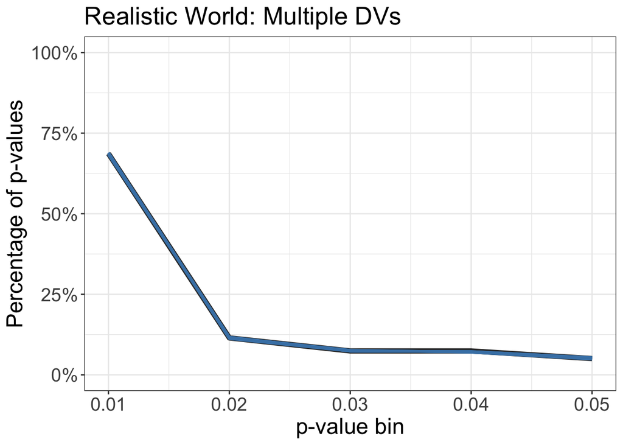

```r
plot_pcurves(simres |> filter(condition == "multDV_realistic"), poriginal = simplify2array(pcurves[2, paste0("p", 1:5)]), n_best = 5, GOF="g2", n_studies = pcurves$nsig[1], tol = 1e-6, title = "Realistic World: Multiple DVs")
```

**Realistic: Optional Stopping**

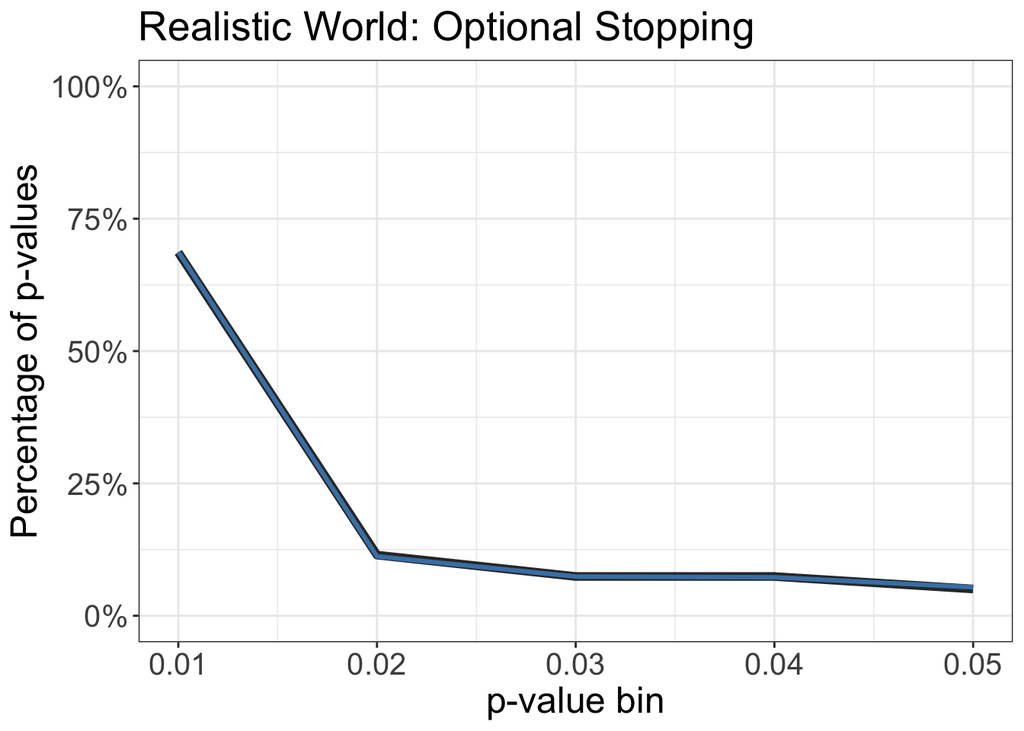

```r
plot_pcurves(simres |> filter(condition == "optStop_realistic"), poriginal = simplify2array(pcurves[2, paste0("p", 1:5)]), n_best = 1, GOF="g2", n_studies = pcurves$nsig[1], tol = 1e-6, title = "Realistic World: Optional Stopping")
```

**Worst: Multiple DVs**

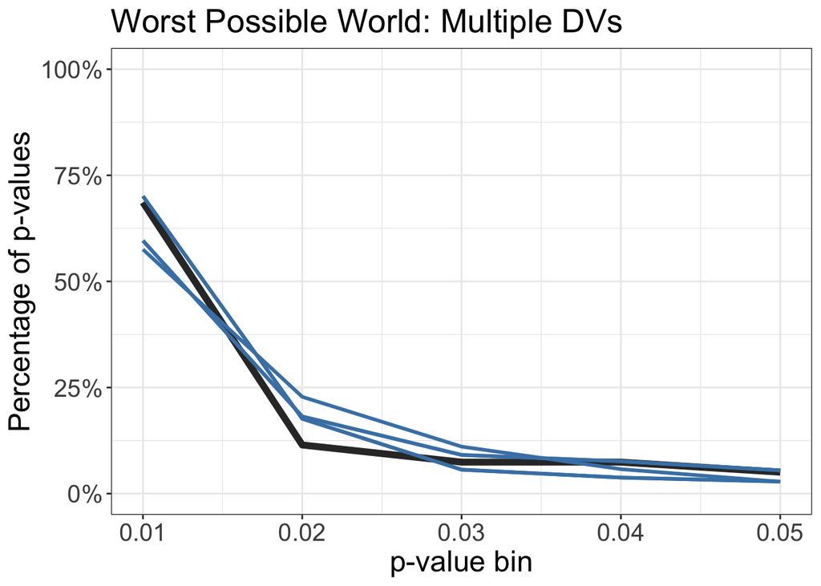

```r
plot_pcurves(simres |> filter(condition == "multDV_worst"), poriginal = simplify2array(pcurves[2, paste0("p", 1:5)]), n_best = 5, GOF="g2", n_studies = pcurves$nsig[1], tol = 1e-6, title = "Worst Possible World: Multiple DVs")
```

**Worst: Optional Stopping**

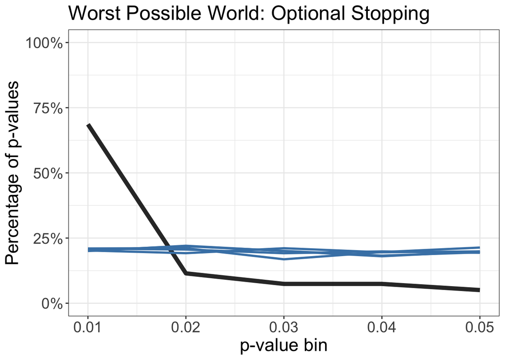

```r
plot_pcurves(simres |> filter(condition == "optStop_worst"), poriginal = simplify2array(pcurves[2, paste0("p", 1:5)]), n_best = 5, GOF="g2", n_studies = pcurves$nsig[1], tol = 1e-6, title = "Worst Possible World: Optional Stopping")
```

**Perfect**

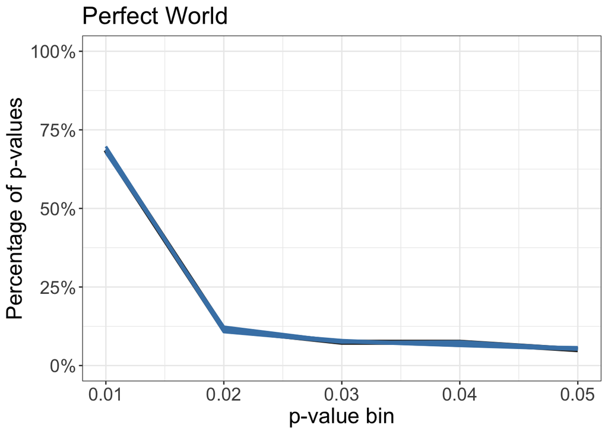

```r
plot_pcurves(simres |> filter(condition == "multDV_perfect"), poriginal = simplify2array(pcurves[2, paste0("p", 1:5)]), n_best = 5, GOF="g2", n_studies = pcurves$nsig[1], tol = 1e-6, title = "Perfect World")
```

**Flat**

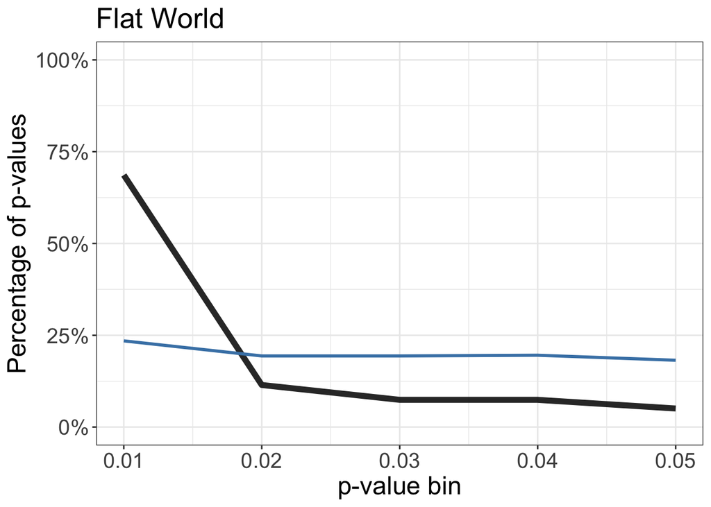

```r
plot_pcurves(simres |> filter(condition == "multDV_H0"), poriginal = simplify2array(pcurves[2, paste0("p", 1:5)]), n_best = 1, GOF="g2", n_studies = pcurves$nsig[1], tol = 1e-6, title = "Flat World")
```

## Overview of best fitting simulations in each world

These fit indices reflect the fit of the best-fitting simulation in each condition/ world. Lower numbers indicate better fit. Note that BIC is a transformation of G2 that penalises for model complexity. ::: {.cell}

```r
fit_tab <- simres %>%
  group_by(condition) %>%
  summarise(
    G2   = min(fit_wetzels_g2),
    BIC  = min(BIC_wetzels),
    Chi2 = min(fit_wetzels_chi2),
    RMSE = min(fit_wetzels_rmse)
  )

fit_tab %>%
  mutate(condition = recode(condition, !!!condition_labels)) %>%
  mutate(across(
    -condition,
    ~ cell_spec(sprintf("%.2f", .x), bold = .x == min(.x))
  )) %>%
  kbl(escape = FALSE) %>%
  kable_styling()
```

| condition | G2 | BIC | Chi2 | RMSE |
| --- | --- | --- | --- | --- |
| Flat World | 555.07 | 555.07 | 678.65 | 0.23 |
| Perfect World | 0.57 | 15.85 | 0.57 | 0.00 |
| Realistic World: Multiple DVs | 0.13 | 30.69 | 0.13 | 0.00 |
| Worst World: Multiple DVs | 26.90 | 42.18 | 24.91 | 0.04 |
| Realistic World: Optional stopping | 0.17 | 35.82 | 0.16 | 0.00 |
| Worst World: Optional stopping | 634.98 | 655.36 | 816.17 | 0.24 |

:::

According to G2, the Realistic World: Multiple DVs contained the best-fitting simulation to the target p-curve. Once model complexity is accounted for, the Perfect World contained the simulation with the best fit to the target p-curve. Results for chi-squared and RMSE are also provided as robustness checks.

## What were the top 10 best fitting simulations (according to G^2)?

These rows reflect the 10 simulations that had the best fit to the target p-curve according to G^2. (Scroll to see the other fit indices for these simulations.)

```r
simres |> arrange(fit_wetzels_g2) |> slice(1:10) |>
  select(condition, nvar, r, d, prop_Hacker, prop_H1, het, strategy, nmin, nmax, stepsize, contains("wetzels")) |>
  kbl(digits = 2) |>
  kable_styling() |>
  scroll_box(width = "100%", height = "400px")
```

| condition | nvar | r | d | prop_Hacker | prop_H1 | het | strategy | nmin | nmax | stepsize | fit_wetzels_g2 | fit_wetzels_chi2 | fit_wetzels_rmse | BIC_wetzels |
| --- | --- | --- | --- | --- | --- | --- | --- | --- | --- | --- | --- | --- | --- | --- |
| multDV_realistic | 2 | 0.0 | 0.7 | 0.50 | 0.5 | 0.0 | 3 | NA | NA | NA | 0.13 | 0.13 | 0 | 30.69 |
| multDV_realistic | 2 | 0.9 | 0.6 | 0.25 | 0.5 | 0.2 | 1 | NA | NA | NA | 0.16 | 0.16 | 0 | 30.72 |
| multDV_realistic | 2 | 0.9 | 0.6 | 0.25 | 0.5 | 0.2 | 2 | NA | NA | NA | 0.16 | 0.16 | 0 | 30.72 |
| optStop_realistic | NA | NA | 0.7 | 0.10 | 0.5 | 0.2 | NA | 8 | 444 | 50 | 0.17 | 0.16 | 0 | 35.82 |
| multDV_realistic | 10 | 0.0 | 0.6 | 0.75 | 0.5 | 0.2 | 1 | NA | NA | NA | 0.20 | 0.20 | 0 | 30.76 |
| multDV_realistic | 10 | 0.0 | 0.6 | 0.75 | 0.5 | 0.2 | 2 | NA | NA | NA | 0.20 | 0.20 | 0 | 30.76 |
| multDV_realistic | 5 | 0.3 | 0.6 | 0.75 | 0.5 | 0.0 | 1 | NA | NA | NA | 0.20 | 0.20 | 0 | 30.76 |
| multDV_realistic | 5 | 0.3 | 0.6 | 0.75 | 0.5 | 0.0 | 2 | NA | NA | NA | 0.20 | 0.20 | 0 | 30.76 |
| optStop_realistic | NA | NA | 0.5 | 0.50 | 0.7 | 0.4 | NA | 50 | 444 | 100 | 0.22 | 0.22 | 0 | 35.88 |
| multDV_realistic | 2 | 0.9 | 0.5 | 0.10 | 0.7 | 0.2 | 1 | NA | NA | NA | 0.35 | 0.34 | 0 | 30.91 |

# 3. Target p-curve: Simonsohn (2014):

## Visualisations of best simulations in each world

You can visually inspect the fit of the top 5 (where available) simulations in each world (in blue) to the target p-curve (in black). Note that the Flat World only involved one simuulation.

**Realistic: Multiple DVs**

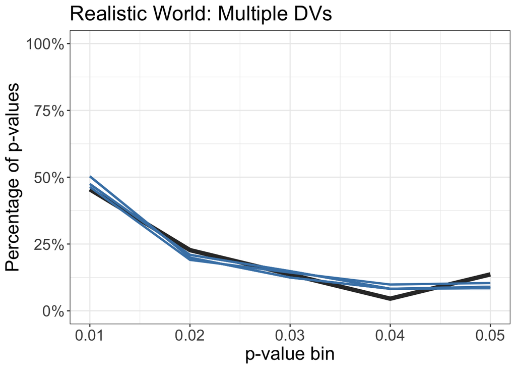

```r
plot_pcurves(simres |> filter(condition == "multDV_realistic"), poriginal = simplify2array(pcurves[3, paste0("p", 1:5)]), n_best = 5, GOF="g2", n_studies = pcurves$nsig[1], tol = 1e-6, title = "Realistic World: Multiple DVs")
```

**Realistic: Optional Stopping**

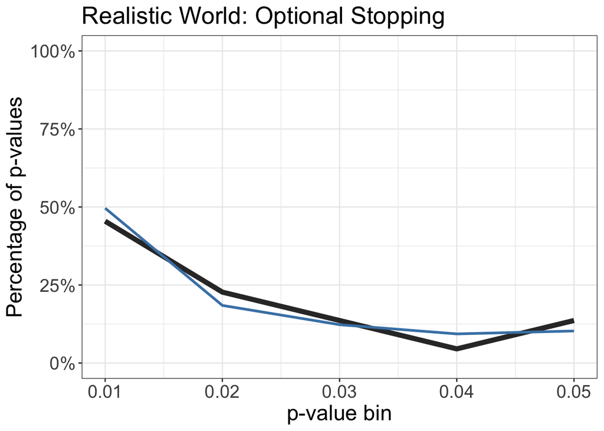

```r
plot_pcurves(simres |> filter(condition == "optStop_realistic"), poriginal = simplify2array(pcurves[3, paste0("p", 1:5)]), n_best = 1, GOF="g2", n_studies = pcurves$nsig[1], tol = 1e-6, title = "Realistic World: Optional Stopping")
```

**Worst: Multiple DVs**

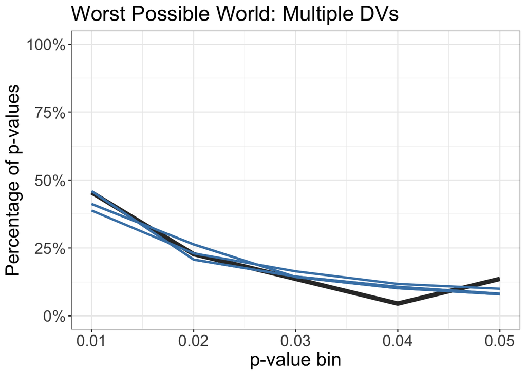

```r
plot_pcurves(simres |> filter(condition == "multDV_worst"), poriginal = simplify2array(pcurves[3, paste0("p", 1:5)]), n_best = 5, GOF="g2", n_studies = pcurves$nsig[1], tol = 1e-6, title = "Worst Possible World: Multiple DVs")
```

**Worst: Optional Stopping**

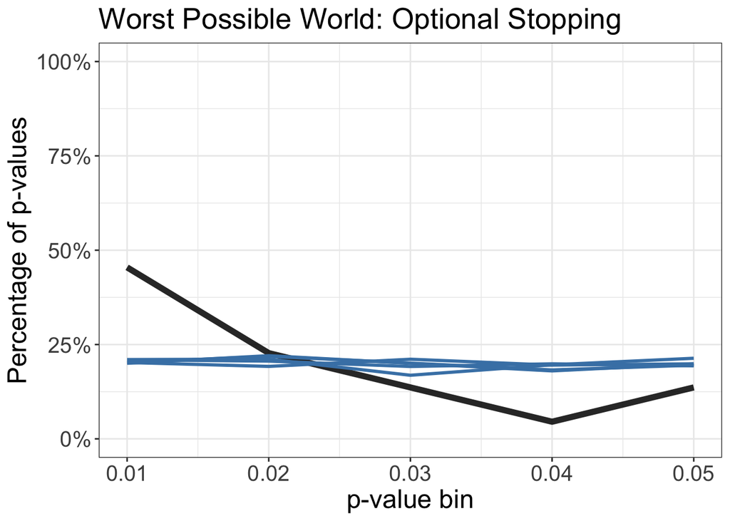

```r
plot_pcurves(simres |> filter(condition == "optStop_worst"), poriginal = simplify2array(pcurves[3, paste0("p", 1:5)]), n_best = 5, GOF="g2", n_studies = pcurves$nsig[1], tol = 1e-6, title = "Worst Possible World: Optional Stopping")
```

**Perfect**

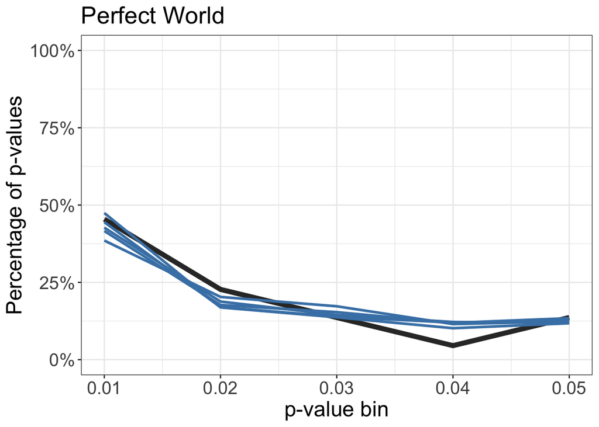

```r
plot_pcurves(simres |> filter(condition == "multDV_perfect"), poriginal = simplify2array(pcurves[3, paste0("p", 1:5)]), n_best = 5, GOF="g2", n_studies = pcurves$nsig[1], tol = 1e-6, title = "Perfect World")
```

**Flat**

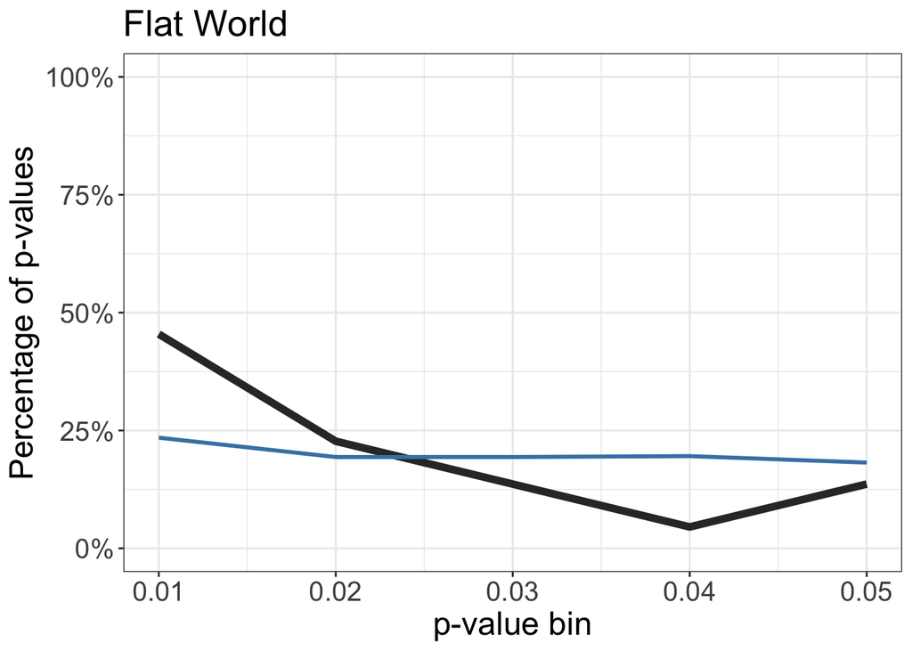

```r
plot_pcurves(simres |> filter(condition == "multDV_H0"), poriginal = simplify2array(pcurves[3, paste0("p", 1:5)]), n_best = 1, GOF="g2", n_studies = pcurves$nsig[1], tol = 1e-6, title = "Flat World")
```

## Overview of best fitting simulations in each world

These fit indices reflect the fit of the best-fitting simulation in each condition/ world. Lower numbers indicate better fit. Note that BIC is a transformation of G2 that penalises for model complexity. ::: {.cell}

```r
fit_tab <- simres %>%
  group_by(condition) %>%
  summarise(
    G2   = min(fit_simonsohn_g2),
    BIC  = min(BIC_simonsohn),
    Chi2 = min(fit_simonsohn_chi2),
    RMSE = min(fit_simonsohn_rmse)
  )

fit_tab %>%
  mutate(condition = recode(condition, !!!condition_labels)) %>%
  mutate(across(
    -condition,
    ~ cell_spec(sprintf("%.2f", .x), bold = .x == min(.x))
  )) %>%
  kbl(escape = FALSE) %>%
  kable_styling()
```

| condition | G2 | BIC | Chi2 | RMSE |
| --- | --- | --- | --- | --- |
| Flat World | 8.05 | 8.05 | 7.81 | 0.12 |
| Perfect World | 1.34 | 16.62 | 1.21 | 0.04 |
| Realistic World: Multiple DVs | 1.10 | 31.66 | 0.97 | 0.03 |
| Worst World: Multiple DVs | 1.72 | 17.00 | 1.60 | 0.04 |
| Realistic World: Optional stopping | 1.20 | 36.85 | 1.05 | 0.04 |
| Worst World: Optional stopping | 9.26 | 29.64 | 9.58 | 0.13 |

:::

According to G2, the Realistic World: Multiple DVs contained the best-fitting simulation to the target p-curve. Once model complexity is accounted for, the Flat World contained the simulation with the best fit to the target p-curve. Results for chi-squared and RMSE are also provided as robustness checks.

## What were the top 10 best fitting simulations (according to G^2)?

These rows reflect the 10 simulations that had the best fit to the target p-curve according to G^2. (Scroll to see the other fit indices for these simulations.)

```r
simres |> arrange(fit_simonsohn_g2) |> slice(1:10) |>
  select(condition, nvar, r, d, prop_Hacker, prop_H1, het, strategy, nmin, nmax, stepsize, contains("simonsohn")) |>
  kbl(digits = 2) |>
  kable_styling() |>
  scroll_box(width = "100%", height = "400px")
```

| condition | nvar | r | d | prop_Hacker | prop_H1 | het | strategy | nmin | nmax | stepsize | fit_simonsohn_g2 | fit_simonsohn_chi2 | fit_simonsohn_rmse | BIC_simonsohn |
| --- | --- | --- | --- | --- | --- | --- | --- | --- | --- | --- | --- | --- | --- | --- |
| multDV_realistic | 70 | 0.3 | 0.1 | 0.25 | 0.7 | 0.0 | 1 | NA | NA | NA | 1.10 | 1.13 | 0.03 | 31.66 |
| multDV_realistic | 70 | 0.3 | 0.1 | 0.25 | 0.7 | 0.0 | 2 | NA | NA | NA | 1.10 | 1.13 | 0.03 | 31.66 |
| multDV_realistic | 70 | 0.0 | 0.2 | 0.10 | 0.3 | 0.0 | 1 | NA | NA | NA | 1.10 | 1.10 | 0.04 | 31.66 |
| multDV_realistic | 70 | 0.0 | 0.2 | 0.10 | 0.3 | 0.0 | 2 | NA | NA | NA | 1.10 | 1.10 | 0.04 | 31.66 |
| multDV_realistic | 150 | 0.6 | 0.1 | 0.25 | 0.5 | 0.2 | 1 | NA | NA | NA | 1.14 | 1.01 | 0.03 | 31.70 |
| multDV_realistic | 150 | 0.6 | 0.1 | 0.25 | 0.5 | 0.2 | 2 | NA | NA | NA | 1.14 | 1.01 | 0.03 | 31.70 |
| multDV_realistic | 2 | 0.9 | 0.5 | 0.25 | 0.1 | 0.2 | 1 | NA | NA | NA | 1.14 | 0.97 | 0.03 | 31.71 |
| multDV_realistic | 2 | 0.9 | 0.5 | 0.25 | 0.1 | 0.2 | 2 | NA | NA | NA | 1.14 | 0.97 | 0.03 | 31.71 |
| multDV_realistic | 70 | 0.3 | 0.2 | 0.10 | 0.3 | 0.2 | 1 | NA | NA | NA | 1.14 | 0.98 | 0.03 | 31.71 |
| multDV_realistic | 70 | 0.3 | 0.2 | 0.10 | 0.3 | 0.2 | 2 | NA | NA | NA | 1.14 | 0.98 | 0.03 | 31.71 |